# Reproducible Research: Peer Assessment 1

## Loading and preprocessing the data

Before trying to read in the data, it first needed to be unzipped.

```r
if(!file.exists("activity.csv")){
  unzip("activity.zip")
}
```

The csv file was read in using the following code.

```r
stepData <- read.csv("activity.csv")
```

The dates were initially read in as factors.

```r
str(stepData)
```

```
## 'data.frame':    17568 obs. of  3 variables:
##  $ steps   : int  NA NA NA NA NA NA NA NA NA NA ...
##  $ date    : Factor w/ 61 levels "2012-10-01","2012-10-02",..: 1 1 1 1 1 1 1 1 1 1 ...
##  $ interval: int  0 5 10 15 20 25 30 35 40 45 ...
```

So they needed to be converted into dates.

```r
library(dplyr)
library(lubridate)
stepData <- mutate(stepData, date = ymd(as.character(stepData$date)))
str(stepData)
```

```
## 'data.frame':    17568 obs. of  3 variables:
##  $ steps   : int  NA NA NA NA NA NA NA NA NA NA ...
##  $ date    : Date, format: "2012-10-01" "2012-10-01" ...
##  $ interval: int  0 5 10 15 20 25 30 35 40 45 ...
```

## What is mean total number of steps taken per day?

First, the daily step totals were calculated.

```r
#Calculating daily totals
dailySteps <- aggregate(stepData$steps, list(stepData$date), sum)

#Renaming dataframe columns
names(dailySteps) <- c("date","steps")
```

Then a histogram of the daily step totals was created.

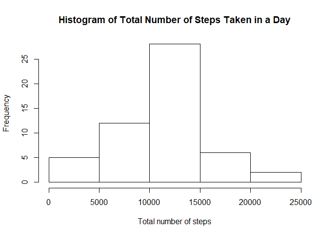

```r
hist(dailySteps$steps, main="Histogram of Total Number of Steps Taken in a Day", xlab="Total number of steps")
```

Finally, the mean and median values of the total number of daily steps were calculated.

```r
#Calculating the mean
mean(dailySteps$steps, na.rm=TRUE)
```

```
## [1] 10766.19
```

```r
#Calculating the median
median(dailySteps$steps, na.rm=TRUE)
```

```
## [1] 10765
```

## What is the average daily activity pattern?

First, the average number of steps taken in each interval were calculated.

```r
#Calculating average number of steps taken in each interval
intervalAvg <- aggregate(stepData$steps, list(stepData$interval), mean, na.rm=TRUE)

#Renaming dataframe columns
names(intervalAvg) <- c("interval", "avgSteps")
```

As the interval values are represented by using the last 2 digits to show the minute and the leading digits to show the hour, the interval values had to be converted to a time value that would be suitable to plot, so a new variable (called time) was created that represented each time interval as the number of hours since midnight.

```r
#Calculting time at each interval (as number of seconds since midnight)
times <- as.numeric(hm(paste(as.character(intervalAvg$interval %/% 100), as.character(intervalAvg$interval %% 100))))
intervalAvg <- mutate(intervalAvg, time=times)

#Converting time from number of seconds since midnight to number of hours since midnight
intervalAvg <- mutate(intervalAvg, time=time/60/60)
```

The average number of steps was then plotted against this new time variable.

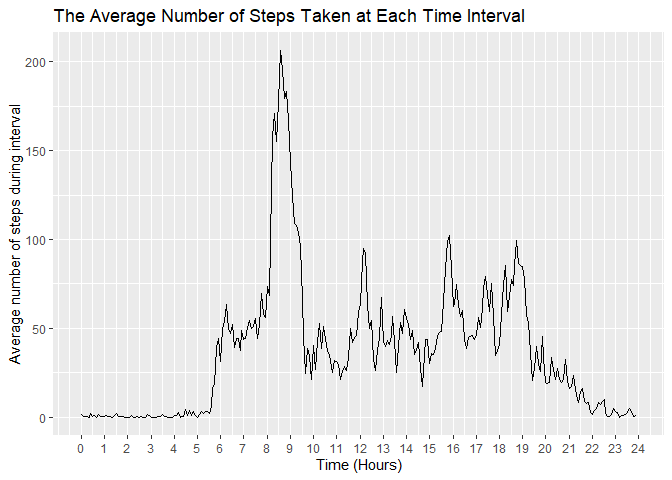

```r
library(ggplot2)
ggplot(intervalAvg, aes(x=time, y=avgSteps)) + geom_line() + scale_x_continuous(breaks=seq(0,24,1)) + ylab("Average number of steps during interval") + xlab("Time (Hours)") + ggtitle("The Average Number of Steps Taken at Each Time Interval")
```

And the interval with highest average number of steps was calculated.

```r
intervalAvg[which.max(intervalAvg$avgSteps), "interval"]
```

```
## [1] 835
```

## Imputing missing values

First the number of rows that conatined any NAs was calculated

```r
sum(!complete.cases(stepData))
```

```
## [1] 2304
```

Then the number of NA values in each column were calculated to see which columns contained NA values.

```r
#Calculating number of NA values in steps
sum(is.na(stepData$steps))
```

```
## [1] 2304
```

```r
#Calculating number of NA values in date
sum(is.na(stepData$date))
```

```
## [1] 0
```

```r
#Calculating number of NA values in interval
sum(is.na(stepData$interval))
```

```
## [1] 0
```

The steps variable was the only one with any NA values, and so a new dataframe was created with these NA values imputed (The NA values were replaced with the average step value for the time interval):

```r
#Creating function that returns the average
avgForInterval <- function(interval, intervalAvg){
  intervalAvg$avgSteps[intervalAvg$interval == interval]
}

#Creating a new dataframe (stepDataImputed) with all NA values replaced with the average step value for that interval
stepDataImputed <- stepData
stepDataImputed[is.na(stepDataImputed$steps),]$steps <- sapply(stepDataImputed[is.na(stepDataImputed$steps),]$interval, avgForInterval, intervalAvg)
```

Then a histogram of the total number of steps per day was created using the data frame with the imputed values.

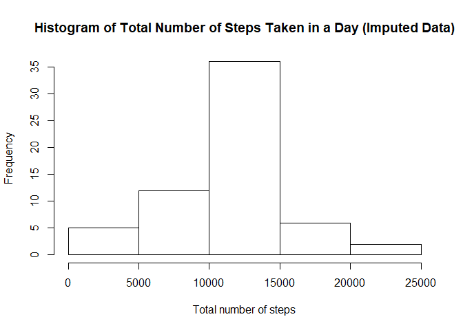

```r
#Calculating daily totals from the imputed dataframe
daySums <- aggregate(stepDataImputed$steps, list(stepDataImputed$date), sum)

#Renaming dataframe columns
names(daySums) <- c("date", "totalSteps")

#Creating histogram
hist(daySums$totalSteps, main="Histogram of Total Number of Steps Taken in a Day (Imputed Data)", xlab="Total number of steps")
```

Finally, the mean and median values of the total number of daily steps including imputed values were calculated.

```r
#Calculating the mean
mean(daySums$totalSteps, na.rm=TRUE)
```

```
## [1] 10766.19
```

```r
#Calculating the median
median(daySums$totalSteps, na.rm=TRUE)
```

```
## [1] 10766.19
```

## Are there differences in activity patterns between weekdays and weekends?

First, a new factor was added to indicate whether each observation was taken on a weekday or on the weekend.

```r
#Creating function that assigns a given day to be either a weekend or a weekday
weekend <- function(dayNum){
  if(dayNum==1 | dayNum==7){
    return("weekend")
  }
  else if(dayNum>1 & dayNum<7){
    return("weekday")
  }
  else{
    return(NA)
  }
}

#Applying function to get a list of wether each observation was taken on a weekday or weekend
weekend <- sapply(wday(stepDataImputed$date), weekend)

#Adding new factor variable to each row of the imputed dataframe to indicated wether it was taken on a weekday or weekend
stepDataImputed <- mutate(stepDataImputed, wEnd=factor(weekend, levels=c("weekday","weekend")))
```

Time series plots were then created to show the average number of steps taken at each interval across both weekdays and weekends.

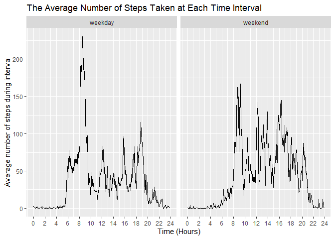

```r
#Calculating the average number of steps in each interval on both weekdays and weekends
avgStepsByWeekend <- stepDataImputed %>% group_by(wEnd, interval) %>% summarize(avgSteps = mean(steps))

#Calculting time at each interval (as number of seconds since midnight)
avgStepsByWeekend <- mutate(avgStepsByWeekend, time=times)

#Converting time from number of seconds since midnight to number of hours since midnight
avgStepsByWeekend <- mutate(avgStepsByWeekend, time=time/60/60)

#Plotting time series graph of the average number of steps against the time variable, with two panels to show how this varied between weekdays and weekends.
ggplot(avgStepsByWeekend, aes(x=time, y=avgSteps)) + geom_line() + facet_wrap(. ~ wEnd) + scale_x_continuous(breaks=seq(0,24,2)) + ylab("Average number of steps during interval") + xlab("Time (Hours)") + ggtitle("The Average Number of Steps Taken at Each Time Interval")
```